# Lecture 06

# Lecture 06 - Linear Regression, Multiple Linear Regression, ANOVA, ANCOVA: Choosing the Best Model for the Job

# Student Name: Live HTML testing

# Student ID:

Image courtesy of [XKCD](https://xkcd.com/1725/)

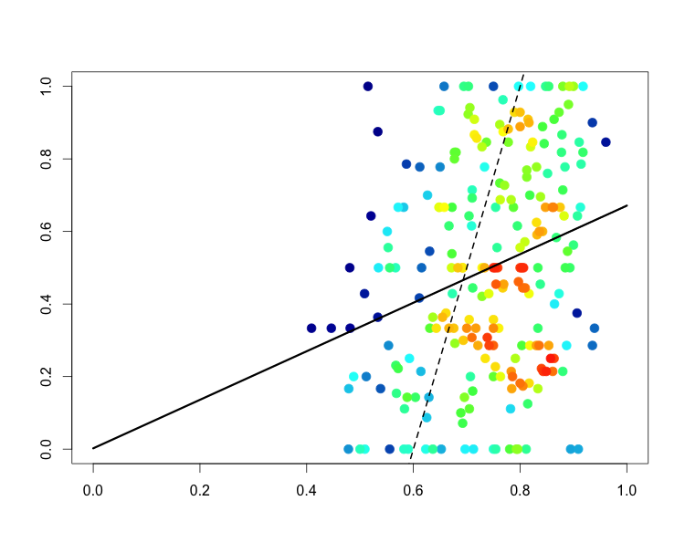

Sometimes plots can be confusing to extrapolate data from!

## 0.1.0 About Introduction to R

Introduction to R is brought to you by the **Centre for the Analysis of Genome Evolution & Function (CAGEF)** bioinformatics training initiative. This course was developed based on feedback on the needs and interests of the Department of Cell & Systems Biology and the Department of Ecology and Evolutionary Biology.

The structure of this course is a code-along style; It is 100% hands on! A few hours prior to each lecture, links to the materials will be available for download at [QUERCUS](https://q.utoronto.ca/). The teaching materials will consist of an R Markdown Notebook with concepts, comments, instructions, and blank coding spaces that you will fill out with R by coding along with the instructor. Other teaching materials include a live-updating HTML version of the notebook, and datasets to import into R - when required. This learning approach will allow you to spend the time coding and not taking notes!

As we go along, there will be some in-class challenge questions for you to solve either individually or in cooperation with your peers. Post lecture assessments will also be available (see syllabus for grading scheme and percentages of the final mark) through [DataCamp](https://Datacamp.com) to help cement and/or extend what you learn each week.

### 0.1.1 Where is this course headed?

We’ll take a blank slate approach here to R and assume that you pretty much know *nothing* about programming. From the beginning of this course to the end, we want to take you from some potential scenarios such as…

- A pile of data (like an excel file or tab-separated file) full of experimental observations that you don’t know what to do with it.
- Maybe you’re manipulating large tables all in excel, making custom formulas and pivot tables with graphs. Now you have to repeat similar experiments and do the analysis again.
- You’re generating high-throughput data and there aren’t any bioinformaticians around to help you sort it out.
- You heard about R and what it *could* do for your data analysis but don’t know what that means or where to start.

and get you to a point where you can…

- Format your data correctly for analysis.
- Produce basic plots and perform exploratory analysis.
- Make functions and scripts for re-analysing existing or new data sets.
- Track your experiments in a digital notebook like R Markdown!

### 0.1.2 How do we get there? Step-by-step.

In the first lesson, we will talk about the basic data structures and objects in R, get cozy with the R Markdown Notebook environment, and learn how to get help when you are stuck because everyone gets stuck - a lot! Then you will learn how to get your data in and out of R, how to tidy our data (data wrangling), and then subset and merge data. After that, we will dig into the data and learn how to make basic plots for both exploratory data analysis and publication. We’ll follow that up with data cleaning and string manipulation; this is really the battleground of coding - getting your data into just the right format where you can analyse it more easily. We’ll then spend a lecture digging into the functions available for the statistical analysis of your data. Lastly, we will learn about control flow and how to write customized functions, which can really save you time and help scale up your analyses.

Don’t forget, the structure of the class is a **code-along** style: it is fully hands on. At the end of each lecture, the complete notes will be made available in a PDF format through the corresponding Quercus module so you don’t have to spend your attention on taking notes.

### 0.1.3 What kind of coding style will we learn?

There is no single path correct from A to B - although some paths may be more elegant, or more efficient than others. With that in mind, the emphasis in this lecture series will be on:

1. **Code simplicity** - learn helpful functions that allow you to focus on understanding the basic tenets of good data wrangling (reformatting) to facilitate quick exploratory data analysis and visualization.
2. **Code readability** - format and comment your code for yourself and others so that even those with minimal experience in R will be able to quickly grasp the overall steps in your code.
3. **Code stability** - while the core R code is relatively stable, behaviours of functions can still change with updates. There are well-developed packages we’ll focus on for our analyses. Namely, we’ll become more familiar with the `tidyverse` series of packages. This resource is well-maintained by a large community of developers. While not always the “fastest” approach, this additional layer can help ensure your code still runs (somewhat) smoothly later down the road.

## 0.2.0 Class Objectives

This is the sixth in a series of seven lectures. Last lecture we concluded our journey with data wrangling in the world of regular expressions. This week we will again explore that “clean” data that we’ve learned to generate using the world of statistical models. At the end of this session you will be able to perform simple and multiple linear regression, one- and multi-way analysis of variance (ANOVA) and analysis of covariance (ANCOVA). You will be able to interpret the statistics that come out of this model, be cognizant of the assumptions made by the model, and use F-test and Akaike Information Criterium (AIC) to select the best model for the job.

1. Basic analysis of datasets and their distribution
2. Linear regression models
3. General linear models
4. Review
5. Resources

## 0.3.0 A legend for text format in R Markdown

- `Grey background`: Command-line code, R library and function names. Backticks are also use for in-line code.
- *Italics* or *Bold italics*: Emphasis for important ideas and concepts
- **Bold**: Headers and subheaders
- Blue text: Named or unnamed hyperlinks
- `...` fill in the code here if you are coding along

**Blue box:** A key concept that is being introduced

**Yellow box:** Risk or caution

**Green boxes:** Recommended reads and resources to learn R

**Red boxes:** A comprehension question which may or may not involve a coding cell. You usually find these at the end of a section.

## 0.4.0 Lecture and data files used in this course

### 0.4.1 Weekly Lecture and skeleton files

Each week, new lesson files will appear within your RStudio folders. We are pulling from a GitHub repository using this [Repository git-pull link](https://r.datatools.utoronto.ca/hub/user-redirect/git-pull?repo=https%3A%2F%2Fgithub.com%2Fuoft-csb-datasci%2F2026-06-IntroR&urlpath=rstudio%2F&branch=main). Simply click on the link and it will take you to the [University of Toronto datatools Hub](https://datatools.utoronto.ca). You will need to use your UTORid credentials to complete the login process. From there you will find each week’s lecture files in the directory `/2026-06-IntroR/Lecture_XX`. You will find a partially coded `skeleton.Rmd` file as well as all of the data files necessary to run the week’s lecture.

Alternatively, you can download the R-Markdown Notebook (`.Rmd`) and data files from the RStudio server to your personal computer if you would like to run independently of the Toronto tools.

### 0.4.2 Live-coding HTML page

A live lecture version will be available at [uoft-csb-datasci.github.io](https://uoft-csb-datasci.github.io/2026-06.IntroToR/index.html) that will update as the lecture progresses. Be sure to refresh to take a look if you get lost!

### 0.4.3 Post-lecture materials

At the end of each lecture there will be a completed version of the lecture code released as an HTML file under the Modules section of Quercus.

### 0.4.4 Data used in this session

The dataset we will use for this lesson is from the Summer Institute in Statistical Genetics (SISG) at the University of Washington’s course in Regression and Analysis of Variance by Lurdes Inoue. This lesson uses a lot of material from the [SISG 2016](https://si.biostat.washington.edu/suminst/archives/SISG2016/SM1604) course as well as conceptual material from [Ben Bolker](https://ms.mcmaster.ca/~bolker/). I like this dataset because it has a number of categorical and continuous variables, which allows us to use the same dataset for many models. Also, the variables are familiar (age, BMI, sex, cholesterol), which makes data interpretation easier while we are in the learning stage.

We’ll read the data in and take a look at the structure.

### 0.4.4.1 Dataset 1: SISG-Data-cholesterol.txt

A space-separated file consisting of measurements related to lipid health and haplotype data for variants at loci that may influence these values. We’ll be using this dataset to explore and model relationships between genotype and phenotype.

## 0.5.0 Packages used in this lesson

The following packages are used in this lesson:

- `tidyverse` (tidyverse installs several packages for you, like `dplyr`, `readr`, `readxl`, `tibble`, and `ggplot2`). In particular we will be taking advantage of the `stringr` package this week.
- `car` a companion to applied regression which has helpful tools for the analysis of variance.
- `gee` a generalized estimation equation solver for fitting your data.
- `multcomp` general linear hypothesis testing in parametric models.
- `broom` useful for formatting model output from linear models.

```r
#--------- Install packages to for today's session ----------#
# install.packages("tidyverse", dependencies = TRUE) # This package should already be installed on Jupyter Hub

# None of these packages are already available on JupyterHub
install.packages("car", dependencies = TRUE) # ~6 minutes to install all dependencies
install.packages("gee", dependencies = TRUE) # ~ 3 minutes to install all dependencies
#--------- Load packages to for today's session ----------#
library(tidyverse)
library(car)
library(multcomp) # used for glht()
library(gee) # Generalized Estimation Equation Solver for our Appendix section
library(broom)
```

## 0.6.0 A little stats is a dangerous thing: an important aside about this lecture

I am not a statistician and likely have just enough knowledge to realize that I mostly know nothing about statistics. The tools and methods we discuss today are to familiarize you with the concept of creating simple linear models but you should **always** think deeply about your data and approach it with the right statistical toolset.

Before embarking on your journey, ask if your data meets all the criteria for this type of analysis. Read papers on similar subjects and see what the consensus is!

[figure not shown]

Don’t get trapped on Mount Stupid of the Dunning-Kruger curve! We’re aiming for the Valley! To despair… and beyond!

# 1.0.0 Answering questions with data

In order to work with our data we need to be able to answer some basic questions.

- How do we describe our data?
- How do we test our hypotheses (what model do we use)?
- How do we test our assumptions about the model we are using?
- How do we compare models?
- How do we make a prediction with new values?

These are all really important questions that we may or may not think about as we try to dive in and get our answer as quickly as possible. Today we are going to slow down a bit and think about our data and our models.

Let’s load our dataset today with a new function, `read.delim()`, where we will specify that the file is space-separated with a header.

**Caution: Why use read.delim()?:** Up until now we’ve mostly stuck to functions supplied from the **readr** package, but we’re going back to the base R functions to use **read.delim()** because our data includes row names! If you look closely at the text file, there is one less column header in the first row than the other columns of data in the file. Unfortunately **read_delim()** does not handle this data format correctly whereas **read.delim()** will!

```r
# Load our data with a new function: read.delim
# It will recognize the missing column header and make the first column of data into row names
cholesterol <- read.delim("data/SISG-Data-cholesterol.txt", sep = " ", header=TRUE)

# You can try this and see what happens but the df will not be correct!
# cholesterol <- read_delim("data/SISG-Data-cholesterol.txt", delim = " ", col_names=TRUE)

# Check the structure of our data set
str(cholesterol)
```

```
## 'data.frame':    400 obs. of  9 variables:
##  $ ID       : int  1 2 3 4 5 6 7 8 9 10 ...
##  $ sex      : int  1 1 0 0 1 1 0 0 0 0 ...
##  $ age      : int  74 51 64 34 52 39 79 38 52 58 ...
##  $ chol     : int  215 204 205 182 175 176 159 169 175 189 ...
##  $ BMI      : num  26.2 24.7 24.2 23.8 34.1 22.7 22.9 24.9 20.4 22 ...
##  $ TG       : int  367 150 213 111 328 53 274 137 125 209 ...
##  $ rs174548 : int  1 2 0 1 0 0 2 1 0 0 ...
##  $ rs4775401: int  2 1 1 1 0 2 1 1 1 1 ...
##  $ APOE     : int  4 4 4 1 1 4 1 1 4 5 ...
```

```r
# What does it look like
head(cholesterol)
```

```
##   ID sex age chol  BMI  TG rs174548 rs4775401 APOE
## 1  1   1  74  215 26.2 367        1         2    4
## 2  2   1  51  204 24.7 150        2         1    4
## 3  3   0  64  205 24.2 213        0         1    4
## 4  4   0  34  182 23.8 111        1         1    1
## 5  5   1  52  175 34.1 328        0         0    1
## 6  6   1  39  176 22.7  53        0         2    4
```

### 1.0.1 A brief breakdown of our data

This dataset maps genetic variants (single nucleotide polymorphisms or SNPs) and their relationship to cholesterol (chol) and triglycerides (TG) for 3 genes: *rs174548* (FADS1 - an enzyme in fatty acid desaturation), *rs4775401* (a candidate SNP), and *APOE* (a major apolipoprotein that is known to influence risk for Alzheimer’s disease).

| ID | sex | age | chol | BMI | TG | rs174548 | rs4775401 | APOE |
| --- | --- | --- | --- | --- | --- | --- | --- | --- |
| patient code | Male=0 Female=1 | patient age | cholesterol | Body mass index | triglycerides | genotype C/C = 0 C/G = 1 G/G = 2 | genotype C/C = 0 C/T = 1 T/T = 2 | allele genotype e2/e2 = 1 e2/e3 = 2 e2/e4 = 3 e3/e3 = 4 e3/e4 = 5 e4/e4 = 6 |

Before we progress, let’s reformat some of our columns to be factors

```r
# Update some of the columns into factors to make our lives a little easier down the road
cholesterol <-
  cholesterol %>%
    mutate(sex = as.factor(sex),
           rs174548 = as.factor(rs174548),
           rs4775401 = as.factor(rs4775401),
           APOE = as.factor(APOE))

str(cholesterol)
```

```
## 'data.frame':    400 obs. of  9 variables:
##  $ ID       : int  1 2 3 4 5 6 7 8 9 10 ...
##  $ sex      : Factor w/ 2 levels "0","1": 2 2 1 1 2 2 1 1 1 1 ...
##  $ age      : int  74 51 64 34 52 39 79 38 52 58 ...
##  $ chol     : int  215 204 205 182 175 176 159 169 175 189 ...
##  $ BMI      : num  26.2 24.7 24.2 23.8 34.1 22.7 22.9 24.9 20.4 22 ...
##  $ TG       : int  367 150 213 111 328 53 274 137 125 209 ...
##  $ rs174548 : Factor w/ 3 levels "0","1","2": 2 3 1 2 1 1 3 2 1 1 ...
##  $ rs4775401: Factor w/ 3 levels "0","1","2": 3 2 2 2 1 3 2 2 2 2 ...
##  $ APOE     : Factor w/ 6 levels "1","2","3","4",..: 4 4 4 1 1 4 1 1 4 5 ...
```

### 1.0.2 Use exploratory plots to begin identifying relationships in your dataset

We are ultimately interested in the relationship between the above genetic variants and cholesterol, while controlling for factors such as age and sex. But let’s get our feet wet by starting with the easier **question: is there an association between mean serum cholesterol and age?**

For this question `cholesterol` is the **dependent variable**, or the variable being measured. `Age` is the **independent variable** that we are changing to determine the effect on cholesterol.

**Key Concept: Independent vs dependent variables.** When we discuss our experiments in terms of collecting measurements, the independent variables are ones manipulated by us, the researchers. In the case of our embryo measurements from previous lectures, the worm strains, pathogen strains, and much of our metadata could be considered a form of independent variable. On the other hand, our dependent variable is usually measured or observed and expected to change based on changes, manipulations or differences to the independent variables between groups!

It is always, **always**, *always*, a good idea to make an ‘exploratory’ plot of your data and get an idea of what its distribution looks like. We can start with a simple scatter plot of age and cholesterol.

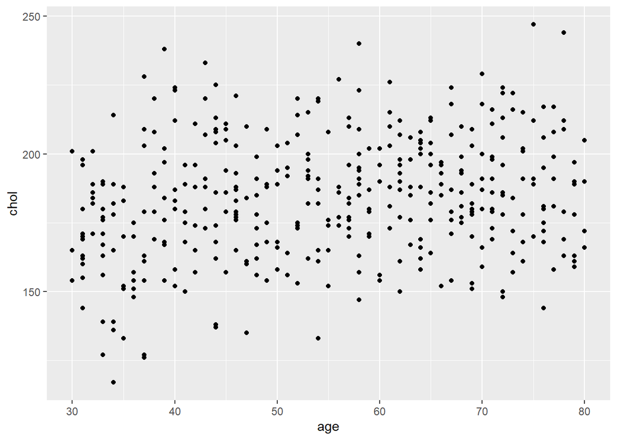

```r
# Plot age vs cholesterol as a scatterplot
# 1. Data
ggplot(cholesterol) +
  # 2. Aesthetics
  aes(x = age, y = chol) +
  # 4. Geoms
  geom_point()
```

### 1.0.3 Generate summary statistics to explore your data

Our data above looks pretty spread out along these axes. Let’s generate some summary statistics to explore it further. We can describe our data with some basic summary statistics such as the mean, median, mode, min, max, standard deviation, and variance (central tendency and dispersion measures). R does not have a mode function relating to statistics, but we can figure it out for ourselves.

```r
#Revisit the structure of our data
str(cholesterol)
```

```
## 'data.frame':    400 obs. of  9 variables:
##  $ ID       : int  1 2 3 4 5 6 7 8 9 10 ...
##  $ sex      : Factor w/ 2 levels "0","1": 2 2 1 1 2 2 1 1 1 1 ...
##  $ age      : int  74 51 64 34 52 39 79 38 52 58 ...
##  $ chol     : int  215 204 205 182 175 176 159 169 175 189 ...
##  $ BMI      : num  26.2 24.7 24.2 23.8 34.1 22.7 22.9 24.9 20.4 22 ...
##  $ TG       : int  367 150 213 111 328 53 274 137 125 209 ...
##  $ rs174548 : Factor w/ 3 levels "0","1","2": 2 3 1 2 1 1 3 2 1 1 ...
##  $ rs4775401: Factor w/ 3 levels "0","1","2": 3 2 2 2 1 3 2 2 2 2 ...
##  $ APOE     : Factor w/ 6 levels "1","2","3","4",..: 4 4 4 1 1 4 1 1 4 5 ...
```

```r
# Pipe our dataset over to the summarise function (mean, median, min, max, sd, variance)
cholesterol %>%
  summarise(mean_chol = mean(chol),
            median_chol = median(chol),
            min_chol = min(chol),
            max_chol = max(chol),
            sd_chol = sd(chol),
            variance_chol = var(chol))
```

```
##   mean_chol median_chol min_chol max_chol  sd_chol variance_chol
## 1   183.915         184      117      247 22.11777      489.1958
```

```r
# We need to calculate mode on our own by sorting
# The table() function creates a frequency table of values
# The sort() function is the base R version of the arrange() verb
mode <- sort(table(cholesterol$chol), decreasing = TRUE)
# Note: we can't use arrange on the resulting table

# We can access table header information using the names() function
# Then we can concatenate values to a printout with the cat() function
cat("\nMost frequent chol value is:", names(mode[1]), "with", mode[1], "occurrences") # most frequent value in our dataset
```

```
##
## Most frequent chol value is: 191 with 12 occurrences
```

**Bonus Info: Why is there no “mode” function in R?** Who knows really but I certainly haven’t found any indication as to why. Of course there are some [packages that can help do this for you](https://www.rdocumentation.org/packages/DescTools/versions/0.99.46/topics/Mode) but we’ve used the [table functions](https://www.rdocumentation.org/packages/base/versions/3.6.2/topics/table) instead to help us make a frequency table from a vector of values. You can actually use this on a dataframe and it will group by factors you choose (or do not excluded) from conversion. You can also try out the [tabulate() function](https://www.rdocumentation.org/packages/base/versions/3.6.2/topics/tabulate) but that’s more focused on calculating frequency from a vector of integers.

### 1.0.4 Make a density plot with `geom_density` to visualize your sample distribution

Our mean (183.9), median (184) and mode (191) are not that different, and so our data is not skewed in either direction. We can also prove this to ourselves by making a quick **density plot** to visualize the residuals (each data point minus the mean)

We’ll make 2 version of the same plot to see that we can either look at the true mean or do a relative comparison by mean-centring around 0.

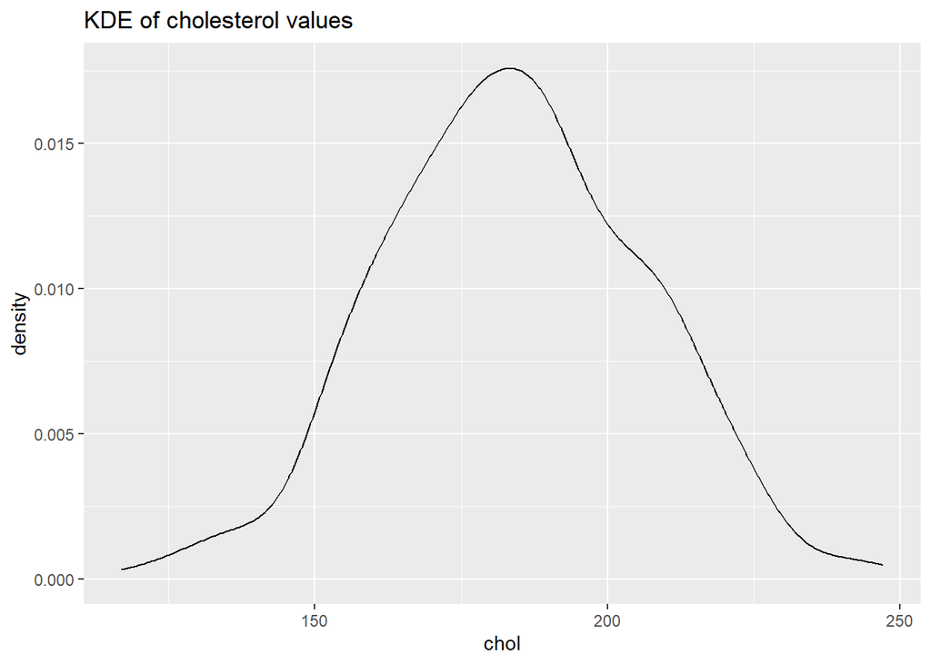

```r
# make a density plot around the mean cholesterol value
# 1. Data
ggplot(cholesterol) +
  # 2. Aesthetics
  aes(x = chol) + # Subtract the mean from each value to centre the distribution around 0

  labs(title = "KDE of cholesterol values") +

  # 4. Geoms
  geom_density() # Use a kernel density estimate
```

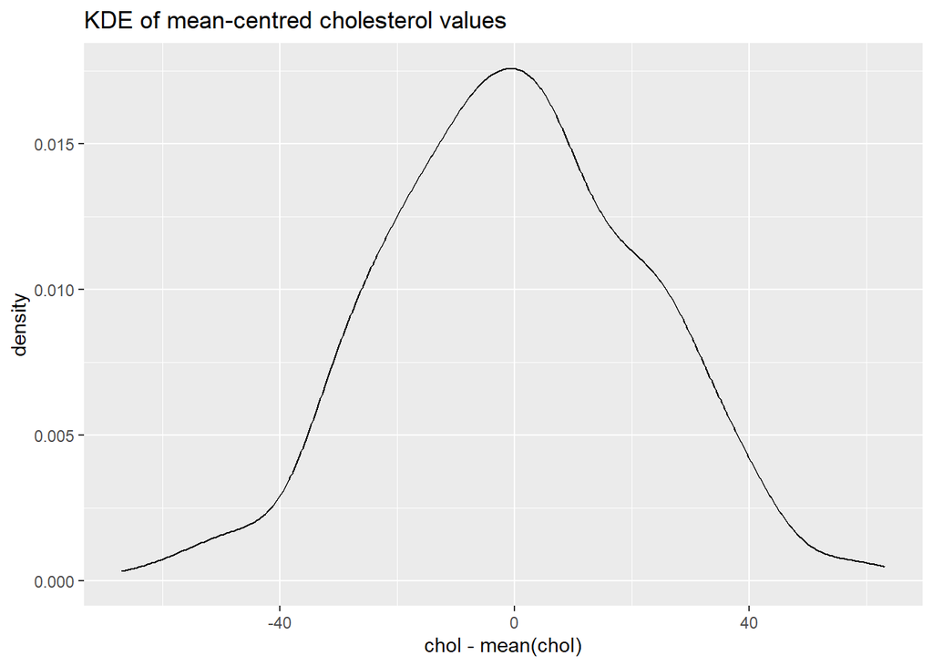

```r
# Centre the mean of the density plot around 0.
ggplot(cholesterol) +
  # 2. Aesthetics
  aes(x = chol - mean(chol)) + # Subtract the mean from each value to centre the distribution around 0

  labs(title = "KDE of mean-centred cholesterol values") +

  # 4. Geoms
  geom_density() # Use a kernel density estimate
```

### 1.0.5 Use `quantile()` to gauge the range of your distribution

Another way to dissect our distribution is by examining the values/boundaries of our dataset when we break it into various portions. We can accomplish the task of breaking up our data using the `quantile()` function. We can set the levels of proportions we want to generate.

Using the default behaviour of `quantile()` generates *quartiles* of our data which will also give us a good sense of the range and distribution of our data.

```r
# Use the default quantile parameters
quantile(cholesterol$chol)
```

```
##     0%    25%    50%    75%   100%
## 117.00 168.00 184.00 199.25 247.00
```

Looking at our quantile output, it reads a bit like a boxplot. 50% of our data lies between cholesterol values of 168 and 199.25 with the median at 184. The extremes of our lower and upper range are 117 and 247.

### 1.0.6 Is age related to cholesterol?

Going back to our question regarding if age is related to cholesterol, let’s add the mean cholesterol to our plot for reference. This is done by adding `geom_hline()` to our plot and specifying the value for the `yintercept`.

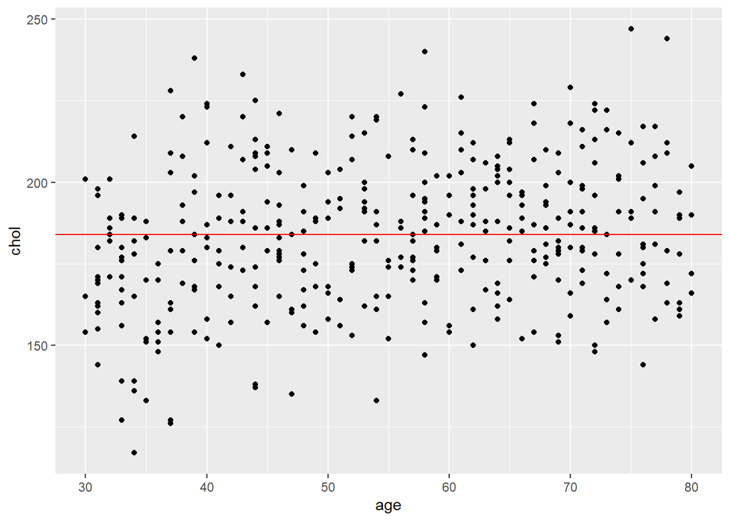

```r
# Modify our scatterplot to include a mean cholesterol value

# 1. Data
ggplot(cholesterol) +
  # 2. Aesthetics
  aes(x = age, y = chol) +
  # 4. Geoms
  geom_point() +                                                  # Add the data points
  geom_hline(yintercept = mean(cholesterol$chol), color = "red")  # Add a simple horizontal line at the mean
```

Despite the mean line going through our centre mass in the plot, the range of cholesterol values may be subtly shifting upwards with age, but how do we test this?

## 1.1.0 Preparing data for a Student’s t-test

T-tests are a simple statistical tool to **compare pairs of means between two groups at the same time**. We don’t currently have age groups, but we can make them. One way to do this is to use our `dplyr` skills to create a new variable `age_group`. The data can be split at 55 years-old (the midpoint of age in our data).

We’ll take advantage of creating a conditional and then casting its logical result to numeric values. Recall that you can cast a logical to numeric with the `as.numeric()` function. Alternatively, we could use the [`ifelse()` function](https://www.datamentor.io/r-programming/ifelse-function) if we wanted to assign values or labels that were not simply `1` or `0`. We’ll learn more about that kind of function in **Lecture 07**.

Remember `mutate(data, new_col = criteria_or_calculation)`

```r
# Add an age_group variable to our cholesterol dataset
cholesterol <-
  cholesterol %>%
  mutate(age_group = as.factor(as.numeric(age > 55)))

# Check our updated dataset
str(cholesterol)
```

```
## 'data.frame':    400 obs. of  10 variables:
##  $ ID       : int  1 2 3 4 5 6 7 8 9 10 ...
##  $ sex      : Factor w/ 2 levels "0","1": 2 2 1 1 2 2 1 1 1 1 ...
##  $ age      : int  74 51 64 34 52 39 79 38 52 58 ...
##  $ chol     : int  215 204 205 182 175 176 159 169 175 189 ...
##  $ BMI      : num  26.2 24.7 24.2 23.8 34.1 22.7 22.9 24.9 20.4 22 ...
##  $ TG       : int  367 150 213 111 328 53 274 137 125 209 ...
##  $ rs174548 : Factor w/ 3 levels "0","1","2": 2 3 1 2 1 1 3 2 1 1 ...
##  $ rs4775401: Factor w/ 3 levels "0","1","2": 3 2 2 2 1 3 2 2 2 2 ...
##  $ APOE     : Factor w/ 6 levels "1","2","3","4",..: 4 4 4 1 1 4 1 1 4 5 ...
##  $ age_group: Factor w/ 2 levels "0","1": 2 1 2 1 1 1 2 1 1 2 ...
```

## 1.2.0 Does your data meet the *minimum* criteria?

A **t-test** is a fairly straightforward, yet powerful test, to determine if two means are statistically (significantly) different. However, there are some **assumptions** (criteria) that our data needs to meet in order to apply a t-test:

- Continuous/ordered scale
- Randomness: samples were taken randomly from the population and and are independent from each other
- Normality: the populations where the samples came from follows a normal distribution (bell-shape) **
- Homoscedasticity (variance homogeneity): the variance of samples are finite and approximately equal ** ** Not necessarily a strict requirement

The first two assumptions have more to do with the nature of values/measurements you are making. For instance, if your measurements are qualitative like “short, average, and tall” then you cannot properly compare your populations with a Student’s t-test. Furthermore, your samples should be independent from one another (as much as possible). Don’t measure the same person multiple times. Measuring the height of an entire family may skew the results if you are mixing those in with other samples that are completely unrelated.

The third and fourth assumptions have more to do with the *shape* of your data and in many cases are considered flexible.

### 1.2.1 Is normality a necessary requirement?

The third assumption, the requirement for normality, depends on your sample size and our friend the Central Limit Theorem.

Let’s begin with the case of **large sample sizes**. If both of your populations are sufficiently large, ie n > 30, where n is the number of samples in each group, then the Central Limit Theorem likely applies. The Central Limit Theorem suggests that even if the original population does not come from a normal distribution, that a *sufficiently large* sampling of the population to create a sample of means *from that population* will *approximate a normal distribution*.

That means if we were to take multiple large sets of samples from the original population, the **mean of the sampling sets** would converge on a normal distribution - despite the shape of the original data! As a corollary to this, even if your original data wasn’t normally distributed, you can take a single sampling using standard sampling rules and a large enough sample size to meet the normality assumption of a parametric t-test!

**Key Concept: using the central limit theorem for t-tests.** If you’re feeling a bit confused on the concept, [Josh Starmer over at the StatQuest Youtube](https://www.youtube.com/watch?v=YAlJCEDH2uY) channel can clear it up for you. He actually shows, in practice, that you can achieve reasonable replication of CLT even when sampling *just 20 times*.

Now, in the case of **small sample sizes** (less than 30 observations also denoted as n < 30) you should consider testing for normality. However, when your sample size is < 10, a standard test for normality such as Shapiro-Wilk, cannot reliably determine this property. Thus, if your sample size is too small, you cannot even begin to assess normality. For samples of n, where 10 <= n < 30, you could theoretically use a Shapiro-Wilk to confirm normality but you may find the results hard to interpret!

The **key concern for this assumption** is that our collected data accurately represents the mean of our population. When sample size is small, the observations may not properly reveal that your data is heavily skewed, or perhaps multimodal. Thus in the case of small sample sizes, it may be in your best interests to use a non-parametric t-test such as the Mann-Whitney U test instead.

Also, if you have **low confidence in whether or not your sampling is representative of the true population**, you can use a non-parametric test like the [Mann-Whitney U test](https://www.researchgate.net/publication/49619432_The_Mann-Whitney_U_A_Test_for_Assessing_Whether_Two_Independent_Samples_Come_from_the_Same_Distribution), which doesn’t care about the specific distribution shape of your data *as long as they are similarly shaped*. This test really compares the location of the *median* between your two populations and whether or not they differ. It is still a very powerful set of tests and eschews the need for normality!

Let’s take a look at our populations again. From above, the density plot we generated suggests values are part of a normal distribution but what happens when we look at our partitioned data?

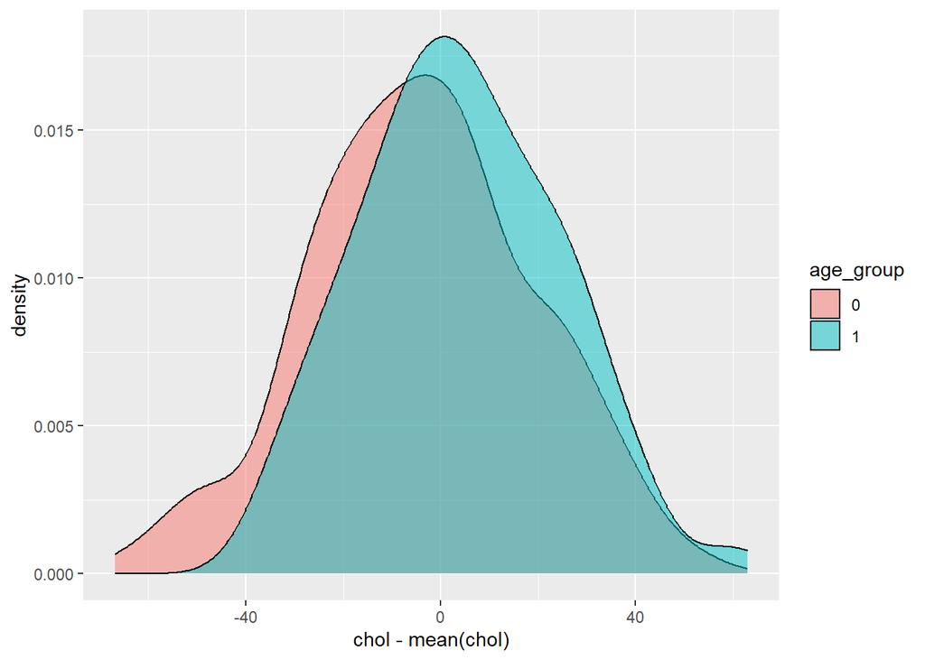

```r
# make a density plot around the mean cholesterol value
# 1. Data
ggplot(cholesterol) +
  # 2. Aesthetics
  aes(x = chol - mean(chol), fill = age_group) + # Subtract the mean from each value to centre the distribution around 0
  # 4. Geoms
  geom_density(alpha = 0.5) # Use a kernel density estimate
```

Our two groups actually still look quite normal, and appear to have a similar variance too! There are, however, some mathematical ways you could test for this information as mentioned above.

### 1.2.2 Shapiro-Wilk test for normality

This is a common test for normality that essentially compares your data to a normal distribution and provides a *p-value* for the likelihood of the null hypothesis. The NULL($H_0$) is that the samples came from the Normal distribution.

Shapiro requires sample size’s between 3 and 5,000. If your p-value $\leq$ 0.05, then you would *reject* the NULL ($H_0$) hypothesis - suggesting your data is *not* from a normal distribution.

To use the Shapiro-Wilk test, we turn to the `shapiro.test()` function which returns a list with 4 elements.

```r
# What kind of output does this test create?
str(shapiro.test(cholesterol$chol))
```

```
## List of 4
##  $ statistic: Named num 0.997
##   ..- attr(*, "names")= chr "W"
##  $ p.value  : num 0.774
##  $ method   : chr "Shapiro-Wilk normality test"
##  $ data.name: chr "cholesterol$chol"
##  - attr(*, "class")= chr "htest"
```

```r
# Run the Shapiro-Wilks on both age groups
shapiro.test(cholesterol$chol[cholesterol$age_group == 0]) # 55 years and younger
```

```
##
##  Shapiro-Wilk normality test
##
## data:  cholesterol$chol[cholesterol$age_group == 0]
## W = 0.99489, p-value = 0.7306
```

```r
shapiro.test(cholesterol$chol[cholesterol$age_group == 1]) # Older than 55 years
```

```
##
##  Shapiro-Wilk normality test
##
## data:  cholesterol$chol[cholesterol$age_group == 1]
## W = 0.99166, p-value = 0.311
```

```r
# Normality test for all cholesterol levels, regardless of the age group
# H0 or null hypothesis: samples come from a population that follows a normal distribution
# H1: samples come from a population that does not follows a normal distribution (the opposite of H0).
# In hypothesis testing, you're not trying to prove H1 but to reject H0.

# What happens when we take the log of our data?
shapiro.test(log(cholesterol$chol))
```

```
##
##  Shapiro-Wilk normality test
##
## data:  log(cholesterol$chol)
## W = 0.98982, p-value = 0.007116
```

So our two age groups fail to reject the null hypothesis, meaning they are still considered normal distributions. Notably, if we log-transform our data, as we did above, the Shapiro-Wilk test rejects our $H_0$, suggesting that the transformed data **is not** normally distributed. Is it necessary for us to separately test each group?

### 1.2.2.1 The `shapiro.test()` returns a list object

Before we continue, it’s always important to see if you can streamline your analyses! What if, our age groupings were much more diverse, leading us to have more than just 2 populations to test? Rather than testing each separately, we can take advantage of the output from the `shapiro.test()` function to `summarise()` our data.

With a little experimentation, we can discover that `shapiro.test()` produces a list with 4 elements:

- `statistic` - this is the “W” value that we see in the above output
- `p.value` - this is the significance values assigned to the rejection of our $H_0$. Remember that a smaller value (< 0.05) means rejection!
- `method` and `data.name` - information on the kind of test performed and the data origins, respectively.

Knowing this is the case, we can treat the output from `shapiro.test()` like a named list, which we can access specifically via the `summarise()` function.

```r
# Use group_by and summarise to analyse multiple subsets of your data for normality
cholesterol %>%
  # Subgroup data by age_group
  group_by(age_group) %>%
  # Apply shapiro-wilks to each group and save the data you want
  summarise(W = shapiro.test(chol)$statistic,
            pvalue = shapiro.test(chol)$p.value)
```

```
## # A tibble: 2 x 3
##   age_group     W pvalue
##   <fct>     <dbl>  <dbl>
## 1 0         0.995  0.731
## 2 1         0.992  0.311
```

**Caution: Shapiro-Wilks produces 2 values.** As you can see from our results, our test produces 2 values **W** and **p-value**. In most cases, we would look directly at the p-value to ascertain if our test rejects the null hypothesis. However, it may be the case that this test [rejects large, nearly normal distributions](https://math.stackexchange.com/questions/3124839/interpretation-of-the-p-value-and-the-test-statistic-w-of-the-shapiro-test-in-r) as well as potentially accepting small, non-normal distributions.

When it comes to the **p-value** it can generally be accepted to tell you of departures from normality but you should always use additional tests (like graphical ones!) to determine if the test is [being overly conservative](https://emilkirkegaard.dk/en/2014/11/w-values-from-the-shapiro-wilk-test-visualized-with-different-datasets). A W-statistic > 0.99 can suggest your distribution is *mostly normally distributed*.

### 1.2.3 Histograms can simulate density

As we mentioned in our `ggplot` class from **lecture 04**, we can generate a quick histogram to look at how our data is roughly distributed. This is similar to a density plot but using the values of our data binned into group. It may, however, look quite familiar to you already.

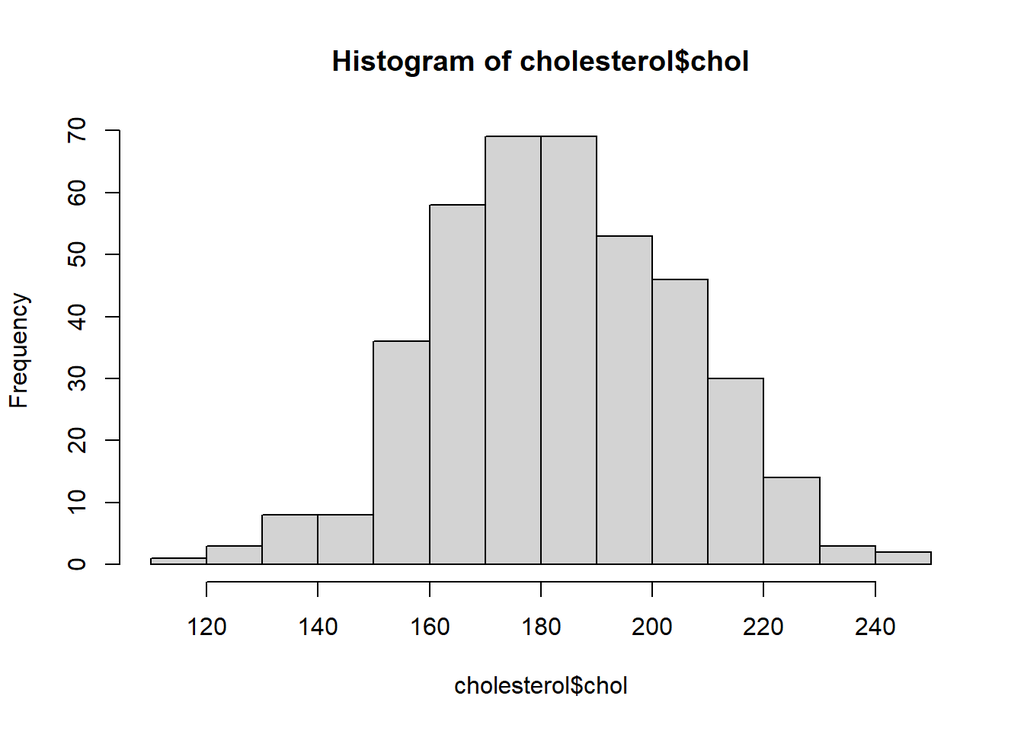

```r
# histogram 2 ways
# Using base R
hist(cholesterol$chol)
```

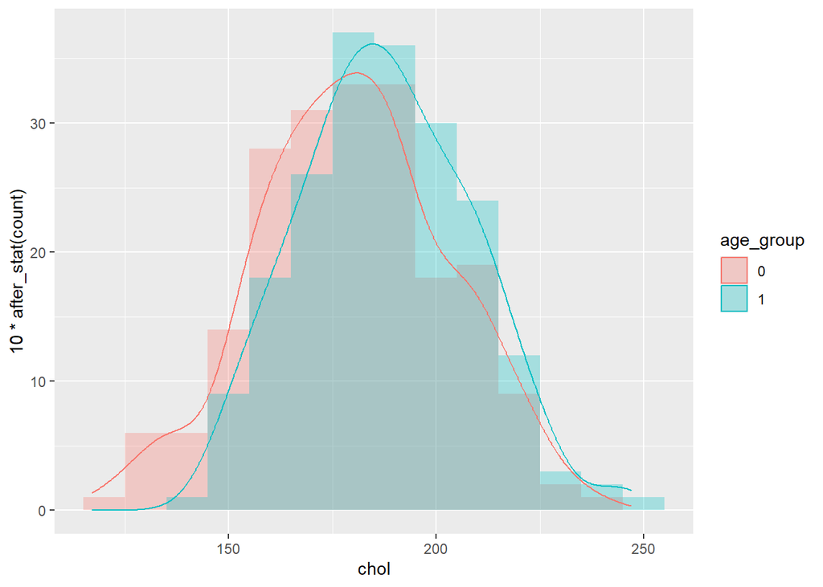

```r
# Using ggplot, let's include a kernel density too
# 1. Data
ggplot(cholesterol) +
  # 2. Aesthetics
  aes(chol, fill = age_group) + # Subtract the mean from each value to centre the distribution around 0
  # 4. Geoms
  geom_histogram(binwidth=10,
                 alpha = 0.3,
                 position = "identity") +

  geom_density(aes(y=10*after_stat(count),
                   colour = age_group), fill = NA) # Use a kernel density estimate
```

```r
  # after_stat will scale the y-axis of the geom
```

### 1.2.4 Quantile-quantile plots

**What is a quantile-quantile plot (Q-Q plot)?**

It’s a scatter plot. More specifically, it’s a scatter plot of your values (sorted in ascending order) against a sample size-matched number of **quantiles** from a chosen theoretical distribution. There are multiple ways to generate a Q-Q plot in R but here we will use:

- `qqnorm()` to check our data against a normal distribution and
- `qqline()` to draw a line going through the first and third quartile

**What do we want to see?**

Essentially a straight line. Depending on the shape and tails, you may need to *transform* your data to match a normal distribution. If that doesn’t seem possible, then you really should not continue with a parametric test like the t-test.

**Bonus Info: More about Q-Q plots.** There are many different distributions that can be identified by the outline of their Q-Q plot and recognizing these can help you decide if you need to take further steps to transform your data (See the Appendix for more details). You can also visit some helpful posts from [around](https://stats.stackexchange.com/questions/101274/how-to-interpret-a-qq-plot) the [internet](https://data.library.virginia.edu/understanding-q-q-plots/) to help clarify these ideas.

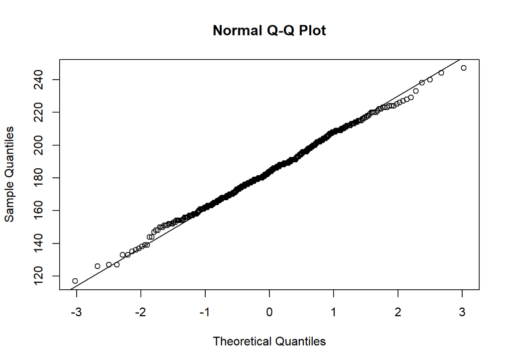

```r
# qqplot of all the data
qqnorm(cholesterol$chol); qqline(cholesterol$chol)
```

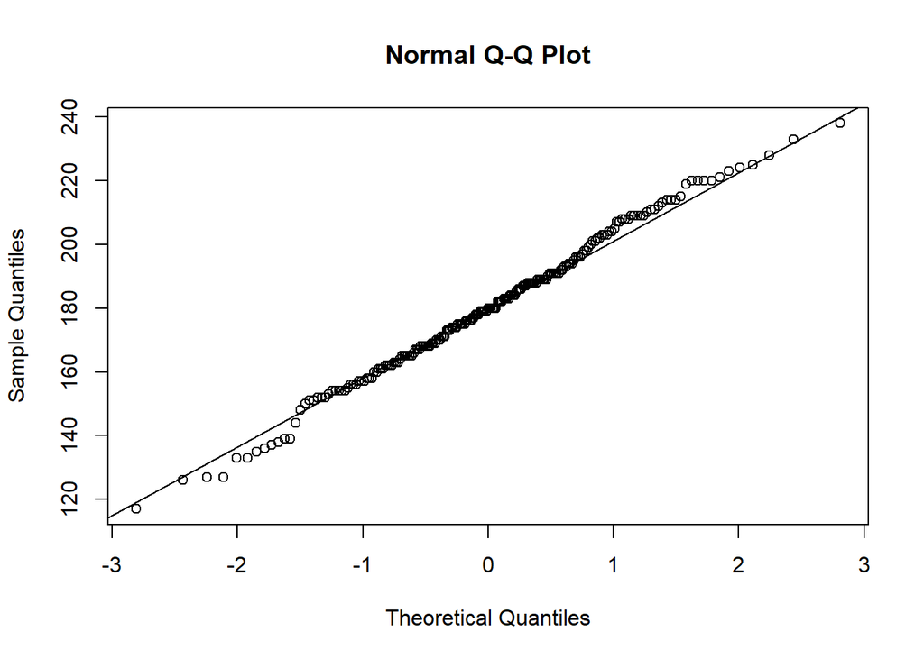

```r
# qqplot of the lower age group data
qqnorm(cholesterol$chol[cholesterol$age_group == 0]); qqline(cholesterol$chol[cholesterol$age_group == 0])
```

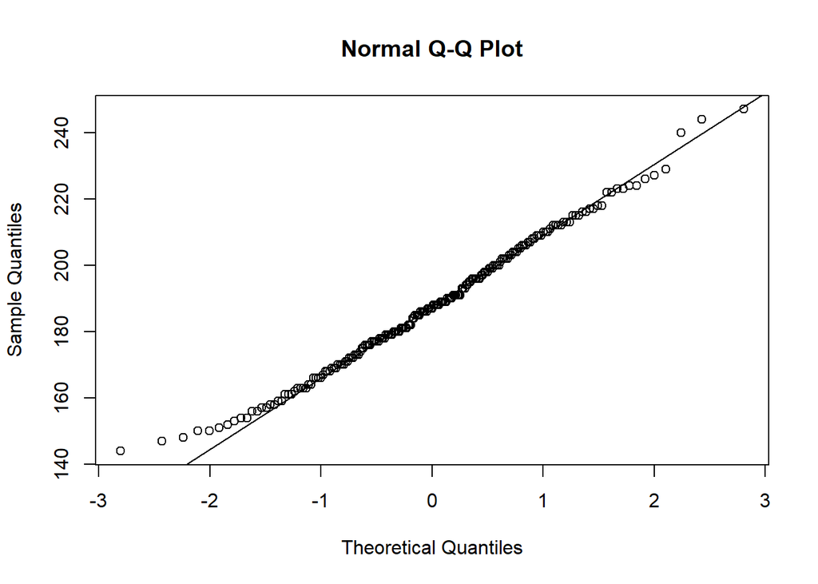

```r
# qqplot of the older age group data
qqnorm(cholesterol$chol[cholesterol$age_group == 1]); qqline(cholesterol$chol[cholesterol$age_group == 1])
```

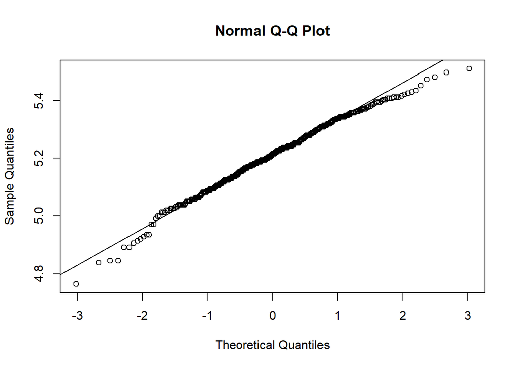

```r
# log transform your data

qqnorm(log(cholesterol$chol)); qqline(log(cholesterol$chol))
```

Looking above at the results of our qq-plot, we see that the total group of data appears to have a normal distribution as most of the points fall along the diagonal line with only a little departure (tailing) on the ends of the line. Splitting the groups apart we also have somewhat normal distributions. You can see from the second age group, that we get some more pronounced tailing at the ends which agrees with the Shapiro-Wilk results that gave this group a lower p-value as well. Again, if the data were log-normalized, you can see much more departure at the ends of our diagonal line.

### 1.2.5 Homoscedasticity looks at the variance of “noise” in our data

The fourth assumption of homoscedasticity, also written as **homoskedasticity** , or equal variance is concerned with the idea that distributions for comparison are the same shape (width and height) so we can compare apples to apples and not apples to oranges. If we assume that both your groups are sufficiently large and thus have a normal distribution anyways, then the Student’s t-test relies on equal variance. The assumption that variances between groups is equal comes up in a number of tests including our t-test.

Again, this is a murky area in that as *n* increases for your sample size, by the CLT, the distribution begins to narrow! So unequal sample sizes can lead to unequal variances! Under ideal conditions you would collect the same number of observations per group but this just isn’t always possible in the wilds of scientific study.

We’ll use Bartlett’s test with `bartlett.test()` which essentially tests if *k* groups have equal variances and returns a K-squared value and p-value against our null hypothesis ($H_0$ = all the groups have equal variance, $H_1$ = at least two of our groups do not have the same variance). A p-value less than our alpha level (ie 0.05) means we reject the null hypothesis. The call we will use takes the form:

`bartlett.test(formula = values ~ grouping, data = dataset)`

where `values ~ grouping` means to use the data from the variable `values` and to group it by `grouping` when retrieving from `dataset`. This kind of syntax may feel familiar to our `facet_*()` layers when using `ggplot`.

Afterwards, we will compare the output of our test against a $\chi^{2}$ value with probability
$$p = (1-\alpha)$$
where $\alpha$ represents our alpha level and the degrees of freedom is calculated as
$$df =
k-1$$
Where $k$ represents the number of groups or categories being compared. In this case, we are comparing 2 groups of variances. We will use the `qchisq(p, df)` function to generate this value. In addition, we will use `qchisq()` to generate the critical value associated with our probability threshold, $\alpha$, given the $df$ we calculate. If our K-squared value < Chi-squared, then it means we didn’t reach the threshold to be considered significant and thus we fail to reject our $H_0$. Likewise, the p-value from Bartlett’s test will be a reflection of this same idea.

**A quick warning**: this test assumes normality for your samples - if this is not the case, a rejection of $H_0$ may be a rejection of normality instead!

```r
## Bartlett's H0: There is homoskedasticity between samples cholesterol of age groups
bartlett.test(chol ~ age_group, data=cholesterol)
```

```
##
##  Bartlett test of homogeneity of variances
##
## data:  chol by age_group
## Bartlett's K-squared = 2.7431, df = 1, p-value = 0.09767
```

```r
#equivalent to
bartlett.test(cholesterol$chol, cholesterol$age_group)
```

```
##
##  Bartlett test of homogeneity of variances
##
## data:  cholesterol$chol and cholesterol$age_group
## Bartlett's K-squared = 2.7431, df = 1, p-value = 0.09767
```

```r
# If Chi-squared > Bartlett's K-squared, then data are homoskedastic (does not reject H0)
qchisq(p = 0.95, df = 1)
```

```
## [1] 3.841459
```

In our case, from the previous tests above, the cholesterol data follows a normal distribution. Based on the Bartlett test results, although the variance between groups is not exactly identical, it is still homoscedastic! Note that the p-value (0.09767) does not meet our alpha level for rejecting $H_0$ and our K-squared value (2.7431) < our $\chi^{2}$ result (3.8414).

If that equality is in question, you can get around this by using a different parametric t-test called the Welch’s t-test which will account for this kind of variation. Thus the fourth assumption can also be circumvented by using a variant of the t-test.

## 1.3.0 Visualize our groups of data further by boxplot

We can also use a boxplot to look at the distribution of cholesterol for our 2 groups. Boxplots are a great way to visualize summary statistics for your data. Recall that:

- The thick line in the center of the box is the median.
- The upper and lower ends of the box are the first and third quartiles (or 25th and 75th percentiles) of your data.
- The whiskers extend from the 1st and 3rd quartiles to the closest values that are no further than **1.5*IQR** (inter-quartile range - the distance between the first and third quartiles).
- Data beyond these whiskers are considered outliers and plotted as individual points.

This visual method is a quick way to see how comparable your samples or groups are.

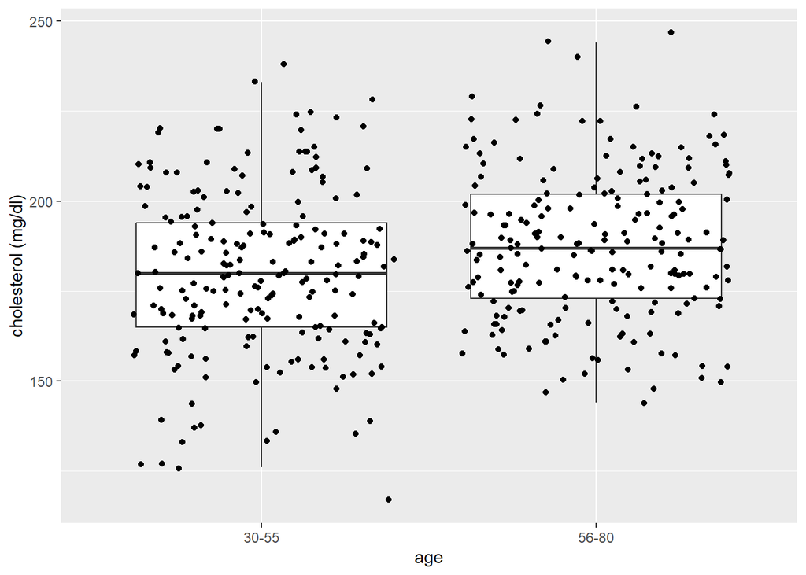

```r
# 1. Data
ggplot(cholesterol) +
  # 2. Aesthetics
  aes(x = age_group, y = chol) +
  xlab("age") +
  ylab("cholesterol (mg/dl)") +
  # 3. Scaling
  scale_x_discrete(labels = c("30-55", "56-80")) +
  # 4. Geoms
  geom_boxplot(outlier.shape = NA) +
  geom_jitter()
```

## 1.3.1 Rules for comparing boxplot groups

When comparing two groups using a boxplot there are some rules of thumb that can be used to quickly indicate statistical significance between the groups. Of course this is under assumptions like unimodal/normally distributed data and you will still need to follow up with an actual test to prove they are statistically significant in their differences, but this method can help prioritize your findings.

1. When the two boxes have no overlap, this means 50% of their distribution (central) is not shared. The medians, by definition, will not be overlapping suggesting a statistically significant difference between the groups.
2. When the boxes overlap, but the median of one sits outside the box of the other, there is strong evidence that the medians are different but not as definitive as non-overlapping boxes.
3. When the boxes are overlapping and the medians of each group are within the box of the other, there is no evidence to suggest the populations are significantly different.

While not 100% conclusive, these considerations are a good rule of thumb when guiding you to your next steps for analysis.

In relation to our plot above, we see that our groups fall into the 3rd category, which matches what we’ve seen thus far in other plots that compare our two groups.

## 1.4.0 Finally, a t-test to compare our distributions

There seems to be a lot of overlap in our cholesterol values. How do we tell if the means are truly different?

Let’s think about this a little more explicitly:

The **null hypothesis (**$H_0$) is that there is no difference in the sample means between our groups.

An **alternative hypothesis (**$H_1$) is that there is a difference between the means (2-sided test), or that the difference in means is greater or lesser than zero (1-sided test).

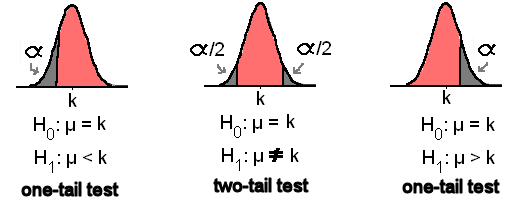

Decide on your $\alpha$ *before* you conduct your study and collect data

$\alpha$ is our p-value, and $\mu$ is the population mean, **k** is our sample mean. Remember that we are *estimating* the true population mean using the sample that we have. The p-value is usually the metric returned when performing most statistical tests. In most cases, we are determining the probability of observing a population **as extreme, or more extreme than** the one calculated from the data made under the assumption that our null hypothesis is true.

We will use a simple **Student’s t-test** to test the alternative hypothesis that the true difference in means is not equal to 0.

The `t.test()` function takes as input the variables on which we are performing the test (as a vector), the “type” of t-test being performed (“two.sided”, “less”, or “greater”), and the confidence interval. The **confidence interval** is the interval that will cover the true parameter x% of the time. Another way to state this is that *if we were to resample multiple times*, thereby regenerating a new confidence interval, our expectation is that the true population means would fall within 95% of these intervals. In the image above the confidence interval covers the pink area, (1-$\alpha$).

You can alternatively enter your variables in a `formula`, in this case `y ~ x`. The `~` in r language is used to separate the left and right sides of a formula. (You can run a 1-sided t-test by specifying `alternative = 'greater'` or `alternative = 'less'`). In this case, `alternative = 'two-sided'` and `conf.level = 0.95` are the default parameters and only included for clarity. For now we are assuming that equal variance is true based on our previous tests.

We also set an additional parameter `var.equal = TRUE` which ensures we are using a Student’s t-test. If set to `FALSE` (the default behaviour), a Welch’s t-test will be run.

```r
#?t.test

# Provide t.test with the two groups of data to compare
t.test(x = cholesterol$chol[cholesterol$age_group == 0], # 55 years or younger
       y = cholesterol$chol[cholesterol$age_group == 1], # 56 years or older
       alternative = "two.sided", conf.level = 0.95, var.equal = TRUE)
```

```
##
##  Two Sample t-test
##
## data:  cholesterol$chol[cholesterol$age_group == 0] and cholesterol$chol[cholesterol$age_group == 1]
## t = -3.6349, df = 398, p-value = 0.0003146
## alternative hypothesis: true difference in means is not equal to 0
## 95 percent confidence interval:
##  -12.202574  -3.636122
## sample estimates:
## mean of x mean of y
##  179.9751  187.8945
```

```r
#is equivalent to
t.test(formula = chol ~ age_group, data = cholesterol, var.equal = TRUE)
```

```
##
##  Two Sample t-test
##
## data:  chol by age_group
## t = -3.6349, df = 398, p-value = 0.0003146
## alternative hypothesis: true difference in means is not equal to 0
## 95 percent confidence interval:
##  -12.202574  -3.636122
## sample estimates:
## mean in group 0 mean in group 1
##        179.9751        187.8945
```

```r
# Much less code to write as well!
```

### 1.4.1 Interpreting our t-test

Our output tells us that the mean cholesterol ($\mu$) for those aged 30-55 is 179.98 mg/dl and the mean for those aged 56-80 is 187.89 mg/dl. The difference in means is significant at a p-value of 0.0003146 (< 0.05). Thus despite how similar these distribution look via boxplot, their means are still statistically significantly different.

We now know that based on our binning, there is a positive relationship between cholesterol and age. However the t-test has limitations. What is the magnitude of this relationship during aging? Does it change by approximately the same amount per year? What if we don’t want to break our data into groups?

For the answer to this, we’ll need to pick up a new toolset.

**Comprehension Question 1.0.0:** Reflect on the methods we’ve discussed to determine if our data set has a normal distribution. Which of these is best, and which should we use first?

**Follow-up question:** why do we even care about our data having a normal distribution?

## Section 1.0.0 comprehension answer:

# 2.0.0 Linear regression models of our dataset

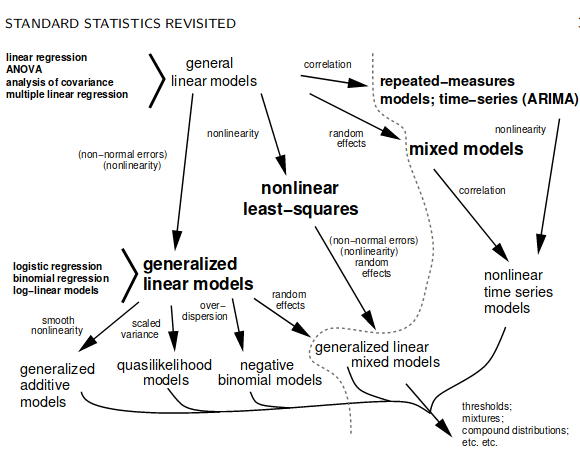

Source: “All (or most) of statistics”. Bolker, 2007.

Can we use a mathematical equation to predict the outcome (dependent variable) based on the values of one or more factors (independent variables)? Certainly! We use observations of the the independent variable to help define the parameters of this relationship to form the mathematical model. One of the simplest explanations of these relationships is that of a linear equation but non-linear models can also be used to explain complex relationships.

There are a ton of models (or families of models) out there for different statistical purposes and with different assumptions. These assumptions, **if violated**, can give incorrect predictions. However, we might not know if these assumptions are true when selecting our model. Today we are hanging out in the top left corner, and we are going to learn the assumptions of *linear models* in general, the specific models we will be using today, and an example of each. We will trouble-shoot when assumptions fail later in the lesson.

First, however, we should discuss those assumptions and then we can talk about when and how to use general linear models!

## 2.1.0 Assumptions of general linear models

1. **Observed values are independent of each other (*independence*)**

The probability of an event occurring does not affect the probability of another event occurring.

2. **Variation around expected values (*residuals*) are normally distributed (*normality*)**

When we generate a general linear model, is the residual or error term constant? Recall that residuals are calculated as the **difference between our real data points and the model** (e.g. line or curve of best fit) that is produced. If the error term differs significantly, constantly, or very erratically across an independent variable (ie `age_group`) then the model is likely missing a large effect from another independent variable.

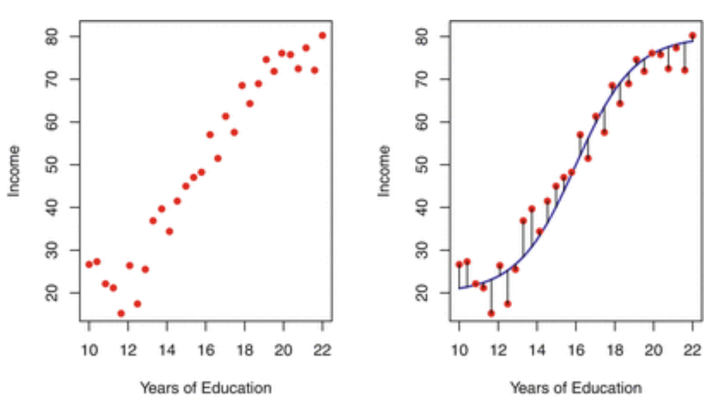

Looking at residual calculation across two continuous variables. Source: “An Introduction to Statistical Learning”. James et al., 2017.

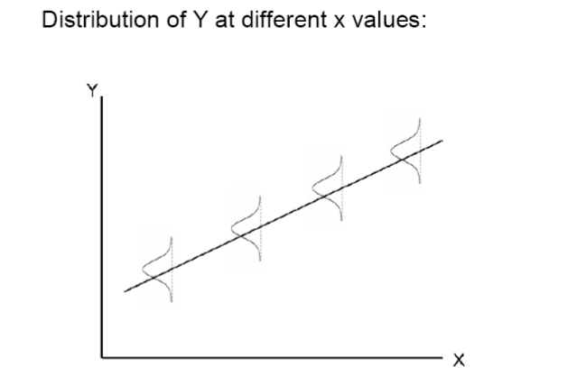

Residual calculation when working with a categorical independen variable. While we may think our data as a line, if we sampled many values at the same x predictor, these values should distribute normally around the y-axis.

**Key Concept: What is a residual?** We often see the word *residuals* thrown around, especially when looking at the analysis of variance. Residuals are the difference between our *measured value* ($y_i$) and the *expected* ($\hat{y_i}$) value of Y given any value $x_i$. How do we calculate the difference from our **expected values**? For some purposes, we can use the words **residuals** and **error** interchangeably to correspond to the difference between our measured values and the *sample mean for any Y | X*.

The meaning of residuals can change slightly when we think about linear models of regression since we are generating “predicted” values based on a model formula rather than simply the mean of a population. In that case our residuals are calculated as **residual = (observed - expected)** (see Section **2.3.1**)

3. **Constant variance, homoscedastic (equal variance)**

It follows from above that *even though your residuals may be normally distributed* at specific values of x, they *must also share the same variance for those distributions* as well.

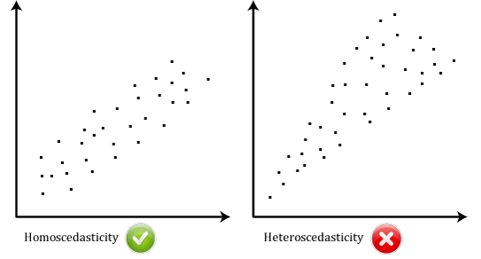

In general, for continuous values of X, values of Y must show equal variance. If you see a funnel or tornado shape, you may have to reconsider your model as the residuals from this linear model may not be homoscedastic.

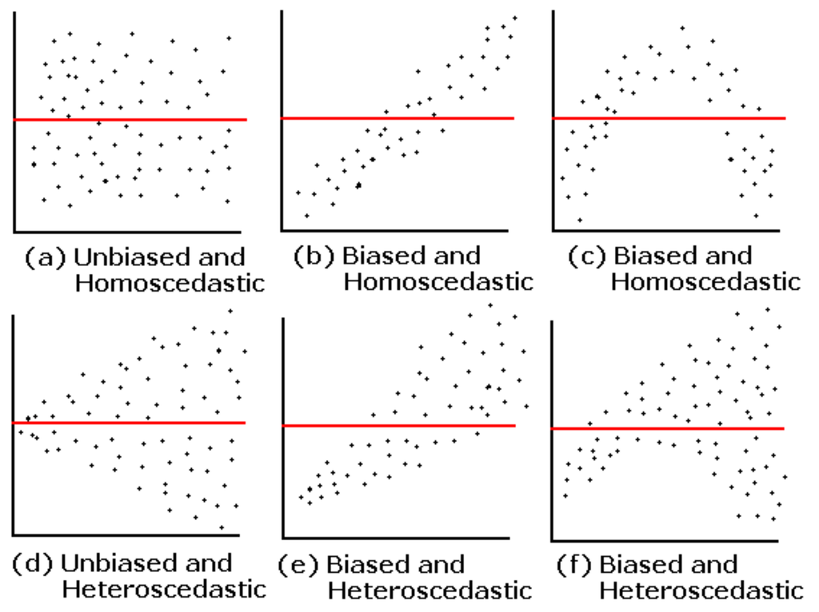

When looking directly at the residuals (y-axis), they can be plotted against their x-axis values. Homoscedastic variance will have a consistently random scattering around the value of 0.

4. **Observed values (y) are related by linear functions of the parameters to x (*linearity*)**

- Example: For $y = a + b_1x+b_2x^2$, the parameters (aka variables) a, b<sub>1</sub>, and b<sub>2</sub> are linear even though the independent variable has a quadratic component, $x^2$. However, $y = ax^b$ is nonlinear with respect to the parameter b, and is not suitable for linear regression.

Assumptions 2 and 3 are often grouped together.

**Caution: Watch out for normality!** It is often confusing when we use the words **normally distributed** with our data for general linear models. Assumption 2 requires that our *residuals* are normally distributed BUT it *does not require* **that our raw data have a normal distribution**. Remember you are trying to model outcomes based across a spectrum of predictor values which can span an unknown range.

In fact, there are studies to support that ANOVA remains quite robust [even in the face of non-normal distributions!](https://econtent.hogrefe.com/doi/abs/10.1027/1614-2241/a000016) However, to be sure of your results, it is best to follow the prerequisite requirements of ANOVA when possible.

## 2.2.0 Linear Models

In the realm of general linear models (not to be confused with *generalized linear models*), there are a five types that we will discuss today which all rely on the assumptions from above.

- **simple linear regression** we are modeling a continuous outcome by a single continuous variable. **Example**: modeling cholesterol using BMI.
- **multiple linear regression** we are modeling a continuous outcome by more than one continuous variable. **Example**: modeling cholesterol using BMI *and* age. In this case, we must consider whether there is an *interaction* between age and BMI on cholesterol (more on interactions to follow).
- *one-way* **ANOVA** (**AN**alysis **O**f **VA**riance) we are modeling a continuous outcome by a single categorical variable. **Example**: modeling cholesterol by sex. It is important that categorical variables are explicitly input as factors to be interpreted properly in the model. For example, since we have encoded sex as 0 and 1 (instead of ‘M’ and ‘F’), we need to specify that sex is to be treated as ordinal and not as a number. Therefore we specify sex as a factor of 2 levels: 0 and 1.
- *multi-way* **ANOVA** we are modeling a continuous outcome by more than one categorical variable. **Example**: modeling cholesterol by sex **and** APOE genetic variants. Again, we need to consider any interaction between our categorical variables, and we need to specify our numeric values to be treated as categorical variables and not numbers. APOE will be a factor of 6 levels, one for each genetic variant.
- **ANCOVA** (**AN**alysis of **COVA**riance) we are modeling a continuous outcome by a *combination* of categorical **AND** continuous variables. **Example**: modeling cholesterol using the genetic variants of APOE and BMI. Again, our categorical variable must be input as a factor. ANCOVA allows for each group (each genetic variant of APOE in this example) to have a separate slope.

This is a summary table you might find helpful for choosing a model based on the data types you have, and the assumptions you are making. I hope to show that model selection is akin to going through a mental checklist for your data, and not that scary.

| model | categorical independent variable | continuous independent variable | linearity | residual normality | residual homoscedasticity |
| --- | --- | --- | --- | --- | --- |
| simple linear regression | X | $\checkmark$ | $\checkmark$ | $\checkmark$ | $\checkmark$ |
| multiple linear regression | X | $\checkmark\checkmark$ | $\checkmark$ | $\checkmark$ | $\checkmark$ |
| one-way analysis of variance (ANOVA) | $\checkmark$ | X | $\checkmark$ | $\checkmark$ | $\checkmark$ |
| multi-way ANOVA | $\checkmark\checkmark$ | X | $\checkmark$ | $\checkmark$ | $\checkmark$ |
| analysis of covariance (ANCOVA) | $\checkmark$ | $\checkmark$ | $\checkmark$ | $\checkmark$ | $\checkmark$ |
| nonlinear least squares | X | $\checkmark$ | X | $\checkmark$ | $\checkmark$ |
| nonlinear ANCOVA | $\checkmark$ | $\checkmark$ | X | $\checkmark$ | $\checkmark$ |
| generalized linear models | $\checkmark$ | $\checkmark$ | X* | X | X |

*restricted cases

**Note**: the independence assumption is required for all the models above, and is not included in the chart for spacing reasons.

### 2.2.1 Revisiting our question

**What is the *relationship* between cholesterol and age?**

Now, we can pick a model to answer our question by considering the assumptions above *instead* of a t-test.

If we evaluate our independent and dependent variables, **age** and **cholesterol**, they are both *continuous*, rather than *categorical*. While our ages are happening at discrete yearly intervals, it is still considered continuous for our purposes. We only have one independent variable. From the plot we made earlier (repeated below) it looks like any possible relationship between age and cholesterol could be linear.

1. The values are independent (from separate blood draws).
2. Data points have an even spread so the residual variance is likely equal and normally distributed.

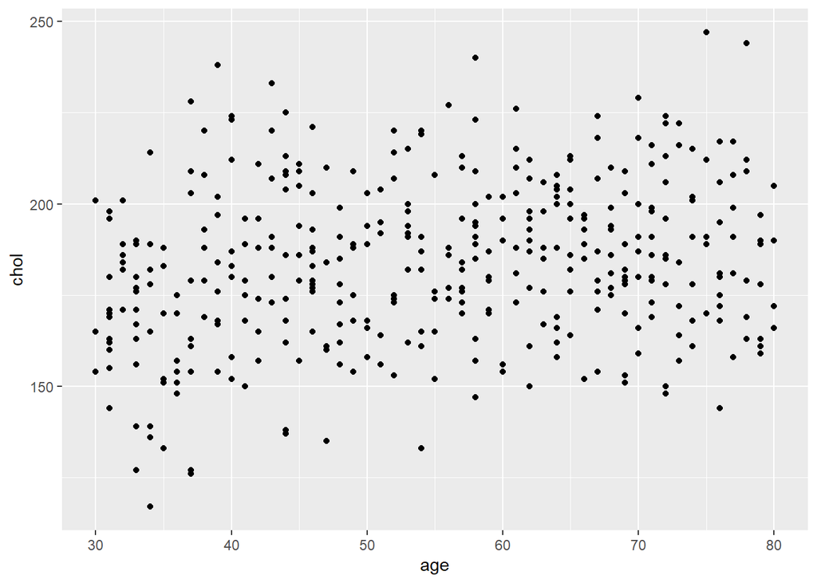

```r
# Show a scatterplot again of age vs cholestorol
# 1. Data

ggplot(cholesterol) +
    # 2. Aesthetics
    aes(x = age, y = chol) +
    # 4. Geoms
    geom_point()
```

Based on the above criteria, we will try using a simple linear regression to test the association between mean serum cholesterol and age.

## 2.3.0 Simple linear regression made simple with `ggplot()`

What we are looking for, is the slope of the line relating cholesterol to age, which will tell us the magnitude and direction of the relationship between these variables. We can look at the slope for the linear model that `ggplot()` would fit for us to get an idea of what our model will look like. We briefly learned how to add a linear model to our plots in **lecture 04** with the `stat_smooth()` layer.

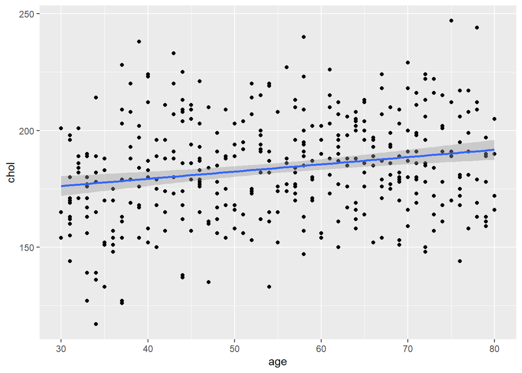

```r
# 1. Data
ggplot(cholesterol) +
  # 2. Aesthetics
  aes(x = age, y = chol) +
  # 4. Geoms
  geom_point() +
  stat_smooth(method = "lm") # Add a stat_smooth as we've seen in the past
```

### 2.3.1 Review: the equation for a straight line.

To make sense of what we’re seeing on our plot, let’s review the equation for a straight line:

$$Y \sim Normal(a + bx,
\sigma^2)$$

- $Y$ is our dependent variable that we are attempting to model.
- $x$ is our independent variable.
- $a$ is the intercept (the value of $Y$ where $x$ = 0; where x crosses the y-axis).
- $b$ is the slope of the line (the change in $Y$ corresponding to a unit increase in $x$).
- $Normal$ is telling us that our error is normally distributed.
- $\sigma^2$ is the variance (squared deviation of the variable x from its mean)

**Slopes**

- A flat line ($b$ = 0) would mean that there is no association between $x$ and $Y$. Thus any value of $x$ will yield a constant predicted value of $Y$.
- The above example has a positive slope, meaning that $Y$ increases as values of $x$ increase.
- With a negative slope, $Y$ decreases as values of $x$ increase.

The **interpretation** in our example is that the slope is the difference in mean serum cholesterol associated with a one year increase in age.

With a straight line we are not, of course, plotting through all of our points, but rather close to the mean of an outcome in y as a function of x. For example, there are only six values of cholesterol for the 50 year-old age group, and our line will fall somewhere close to the mean of these values. Values of $Y$ have a distribution at a given $x$, which we have assumed is normally distributed.

Lastly, in this equation we also have some normally distributed error. Sampling error exists in our estimates because different estimates give different means.

How do we actually find the best fitting line? We use **least squares estimation**, which minimizes the sum of squares of the vertical distances from the observed points to the least squares regression line $(y -\hat{y})^{2}$ where:

- $y$ is the observed value
- $\hat{y}$ is the estimated value
- $\bar{y}$ is the sample mean

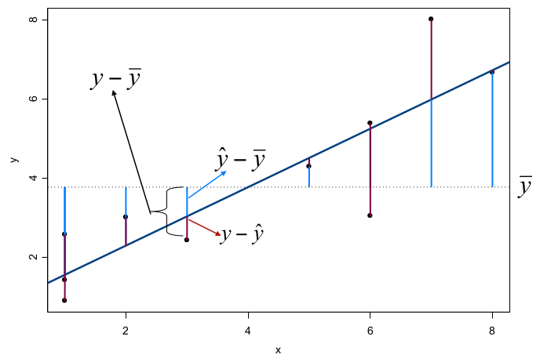

A least squares estimation attempts to minimize overall distance of observed y-values from the estimated y-values for a predictor x within our model

### 2.3.2 Use the `lm()` function to generate a linear model

Let’s run this simple linear regression. Using R, the intercept and slope terms are implicit. We’ll use the `lm()` function just like we do in `geom_smooth()` which will produce output but whose results can also be saved as a list object with all of the information about the model. For now, the `lm()` function has 2 parameters we are most interested in:

- `formula`: takes in an equation expression that defines our linear model.
- `dataset`: the dataset where our values for regression will be found.

In R, a formula takes on the form of `y ~ x`. As we are used to writing equations, our dependent variable (cholesterol) is on the left side of `~` and our independent variable (age) is on the right side. The tilde `~` separates these sides and is actually the key identifier in a formula. This allows R to pass the variable (x and y) information along without evaluating them so that the function *receiving* the data [can do the evaluating](https://www.datacamp.com/tutorial/r-formula-tutorial). You can think of the formula as reading “dependent variable modeled as a function of independent variable(s)”.

**Bonus Info: Setting your y-intercept to 0!** There are times when the intercept, the value of y at x = 0, doesn’t make much intuitive sense to interpret our data. To force the intercept to zero (y = bx) to have relative comparisons instead, use **lm(y ~ 0 + x)**. Adding the 0 term, forces the model to have a y-intercept through 0.

Let’s investigate creating a linear model for explaining the relationship between cholesterol and age.

```r
# Generating a linear model. Looks a lot like the bartlett.test() format right?
lm(formula = chol ~ age, data = cholesterol)
```

```
##
## Call:
## lm(formula = chol ~ age, data = cholesterol)
##
## Coefficients:
## (Intercept)          age
##    166.9017       0.3103
```

The function will output our formula, the slope and the intercept. However, if we save the output of the function into an object, `ageFit`, we get a `list` object of the model, the input, and all associated statistics.

```r
# Assign the linear model to an object
ageFit <- lm(formula = chol ~ age, data = cholesterol)

# ageFit is a list of 12 elements that can be individually accessed by using the dollar operator
str(ageFit, give.attr = FALSE)
```

```
## List of 12
##  $ coefficients : Named num [1:2] 166.9 0.31
##  $ residuals    : Named num [1:400] 25.13 21.27 18.24 4.55 -8.04 ...
##  $ effects      : Named num [1:400] -3678.3 89.45 17.61 1.86 -9.49 ...
##  $ rank         : int 2
##  $ fitted.values: Named num [1:400] 190 183 187 177 183 ...
##  $ assign       : int [1:2] 0 1
##  $ qr           :List of 5
##   ..$ qr   : num [1:400, 1:2] -20 0.05 0.05 0.05 0.05 0.05 0.05 0.05 0.05 0.05 ...
##   ..$ qraux: num [1:2] 1.05 1.02
##   ..$ pivot: int [1:2] 1 2
##   ..$ tol  : num 1e-07
##   ..$ rank : int 2
##  $ df.residual  : int 398
##  $ xlevels      : Named list()
##  $ call         : language lm(formula = chol ~ age, data = cholesterol)
##  $ terms        :Classes 'terms', 'formula'  language chol ~ age
##  $ model        :'data.frame':   400 obs. of  2 variables:
##   ..$ chol: int [1:400] 215 204 205 182 175 176 159 169 175 189 ...
##   ..$ age : int [1:400] 74 51 64 34 52 39 79 38 52 58 ...
```

### 2.3.3 Use `summary()` to look at the salient information about your model

As you can see from looking at the structure, the `lm` model object holds a lot of information. We can use the `summary()` function to pull out some of the more important information about our model instead of wading through all of the data. The `summary()` function can give us a summary of the residuals, errors, p-values and more in addition to our coefficients.

It should be noted, that this information can vary between different types of objects as well.

```r
# Look at the summary information of 'ageFit'
summary(ageFit)
```

```
##
## Call:
## lm(formula = chol ~ age, data = cholesterol)
##
## Residuals:
##     Min      1Q  Median      3Q     Max
## -60.453 -14.643  -0.022  14.659  58.995
##
## Coefficients:
##              Estimate Std. Error t value Pr(>|t|)
## (Intercept) 166.90168    4.26488  39.134  < 2e-16 ***
## age           0.31033    0.07524   4.125 4.52e-05 ***
## ---
## Signif. codes:  0 '***' 0.001 '**' 0.01 '*' 0.05 '.' 0.1 ' ' 1
##
## Residual standard error: 21.69 on 398 degrees of freedom
## Multiple R-squared:  0.04099,    Adjusted R-squared:  0.03858
## F-statistic: 17.01 on 1 and 398 DF,  p-value: 4.522e-05
```

### 2.3.4 Interpreting our linear model

The intercept is 166.9 and the slope is 0.31. What does that actually mean? It means a baby (age 0 or 0 years) would be expected to have on average a serum cholesterol of 166.9 mg/dl. For every yearly increase in age, mean serum cholesterol is expected to increase by 0.31 mg/dl. These results are significant with a p-value < 0.001 (4.52<sup>-05</sup>). We can reject the null hypothesis and say that mean serum cholesterol is significantly higher in older individuals. The Adjusted R-squared value (which accounts for model complexity) tells us that about 4% (0.03858) of the variability in cholesterol is explained by age.

Note there are two sets of p-values presented: `Pr(>|t|)`, and a `p-value` associated with the F-statistic.

- `Pr(>|t|)` is an evaluation of the co-efficient producing this t-statistic against a **null hypothesis in which the true co-efficient is 0**. In looking at the intercept of 166.90, it is the proportion of the t-distribution at df = 398 which is greater than the absolute value of your t-statistic (39.134). So again this is the p-value for seeing a test-statistic value as extreme or more extreme than what we’ve observed under the specific conditions. In the case of our intercept, this is against the null hypothesis of an intercept of 0.
- `p-value` at the end of our summary, tells us about the model overall and whether it is predicting better than just random noise. In this case, it is for a null hypothesis that all your coefficients, except for the y-intercept, are 0. Thus a low p-value will suggest that at least one coefficient is non-zero or significant relatedt o the dependent variable. You’ll notice that in the case of a single continuous predictor, we get the same p-value as Pr(>|t|) for the age variable because it is the only other coefficient. We will discuss F-values a little more in just a few sections.

### 2.3.5 Use `confint()` to generate confidence intervals on your data

Given that we have a model object like our `ageFit` linear model, we can generate a confidence interval using the `confint()` method. By default this function sets the argument `level` to 0.95 or a 95% confidence interval level. Let’s generate a confidence interval for our model parameters.

```r
# Generate a confidence interval with confint()
confint(ageFit)
```

```
##                   2.5 %      97.5 %
## (Intercept) 158.5171656 175.2861949
## age           0.1624211   0.4582481
```

We can further get confidence intervals for these values to say that in 95% of chosen intervals (ie 158.5-175.3 mg/dl in this case) the mean cholesterol of a baby will fall within that interval, or that we are 95% confident that the difference in mean cholesterol associated with a one year increase in age is between 0.16 and 0.46 mg/dl.

**Caution: Be precise about confidence Intervals!** Just a reminder that a 95% confidence interval **does not** mean there is a 95% probability that the true population value (i.e. mean) lies between our range. We don’t know the true population value or how close it is to our estimated value. We know with 100% certainty that it is either inside or outside the interval.

More precisely, the correct interpretation is that if we were to randomly sample from our population *multiple times*, we expect that 95% of our constructed intervals would contain the true population value! Therefore we *can* say with 95% certainty that the interval, as calculated, contains the true population value. It’s a very fine (and often confusing) distinction.

On the bright side, we can also note that a wide interval suggests a less precise estimate vs a small interval. Of course the size of our interval is influenced by our sample size with narrower intervals generated by higher sample numbers. Likewise, using a smaller confidence value (ie 90%) produces a smaller interval as well.

[figure not shown]

It can be hard to be confident with the definition of a confidence interval.

## 2.4.0 Multiple linear regression

In multiple linear regression we use multiple continuous dependent variables to predict outcome values. Additional terms can be added in 2 ways.

### 2.4.1 Adding powers of a variable (polynomial regression)

It was mentioned before that the ‘linear’ part of linear regression is the linear function of the *parameters* and not the independent variables. In the example below, the parameters $a$, $b_1$, and $b_2$ are linear even though the independent variable has a quadratic component, $x^2$. An example of this could be synthesizing a chemical, where with increasing temperature, synthesis progresses with an increasing curve.

*Expression:*

$$Y \sim Normal(a + b_1x + b_2x^2,
\sigma^2)$$
If we were to write this in R, again our intercept and coefficients are implicit. To write the quadratic term we use the function `I()` which just means ‘as.is’. This allows the interpreter to see the `^` as a power symbol and not as an interaction term.

*R code:*

`lm(y ~ x + I(x^2))`

Suppose from our data that we think cholesterol can be modeled by age as a quadratic equation. What would that look like?

```r
# summarize the results of a multiple linear regression
summary(lm(chol ~ age + I(age^2), data = cholesterol))
```

```
##
## Call:
## lm(formula = chol ~ age + I(age^2), data = cholesterol)
##
## Residuals:
##     Min      1Q  Median      3Q     Max
## -56.836 -15.063  -0.654  14.534  60.246
##
## Coefficients:
##               Estimate Std. Error t value Pr(>|t|)
## (Intercept) 120.890937  16.722415   7.229 2.51e-12 ***
## age           2.120309   0.640815   3.309  0.00102 **
## I(age^2)     -0.016562   0.005824  -2.844  0.00469 **
## ---
## Signif. codes:  0 '***' 0.001 '**' 0.01 '*' 0.05 '.' 0.1 ' ' 1
##
## Residual standard error: 21.5 on 397 degrees of freedom
## Multiple R-squared:  0.06014,    Adjusted R-squared:  0.05541
## F-statistic:  12.7 on 2 and 397 DF,  p-value: 4.498e-06
```

It looks like this modification to our model explains our model’s variation (Adjusted R-squared up to 0.05541 from 0.03858) slightly more but doesn’t drastically improve on it. Likewise the p-values of our coefficients are not as low as in our simplified age-related model of cholesterol.

What about incorporating additional independent variables to our model?

### 2.4.2 Adding extra continuous variables to our model

We are interested in improving our model by adding an extra variable we think might have an effect on our outcome values. In the example below, we are adding the independent variables x<sub>1</sub>, x<sub>2</sub>, and each of these terms has their own linear parameter b<sub>1</sub> and b<sub>2</sub>, respectively.

*Expression:*

$$Y \sim Normal(a + b_1x_1 + b_2x_2,
\sigma^2)$$

This is the model we will be using next. To aid with interpretation let’s think about a parameter. b<sub>2</sub> is the expected mean change in unit per change in x<sub>2</sub> if x<sub>1</sub> is held constant (sometimes called controlling for x<sub>1</sub>).

The null hypothesis in this case is that all b<sub>1</sub>, b<sub>2</sub> = 0. The alternative hypothesis is that at least one of these parameters is not null.

Again, in R, the intercept and coefficients are implicit in the `lm` function.

*R code:*

`lm(y ~ x1 + x2)`

We know that age has an effect on cholesterol. With our new model we want to ask the question: **Is there a statistically significant relationship between mean serum cholesterol and age after controlling for BMI?** Let’s look graphically at these relationships to help us understand our model. First let’s plot BMI vs cholesterol. We can add a linear fit to make sure we are expecting a positive slope.

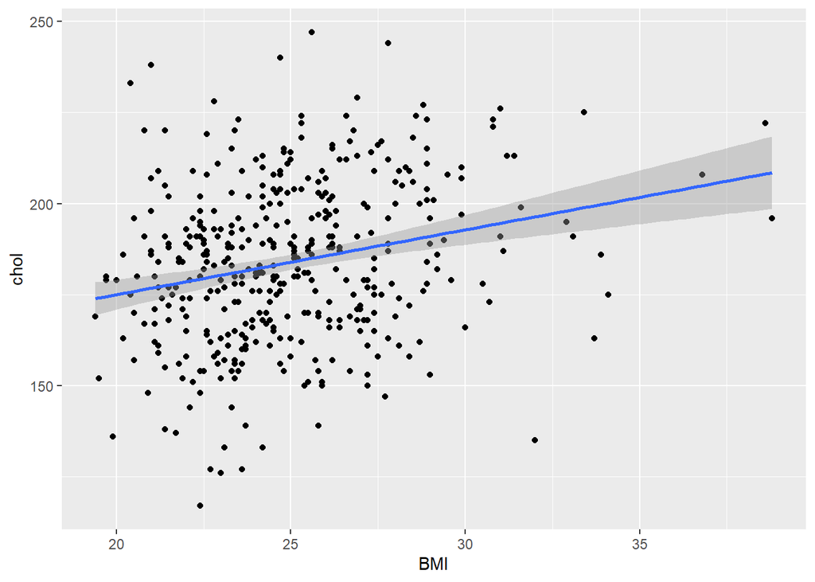

```r
# Plot the relationship between cholesterol and BMI
# 1. Data
ggplot(cholesterol) +
  # 2. Aesthetics
  aes(x = BMI, y = chol) + # Use BMI as the x-value
  # 4. Geoms
  geom_point() +
  stat_smooth(method = "lm")
```

We should also take a look at the relationship between BMI and age.

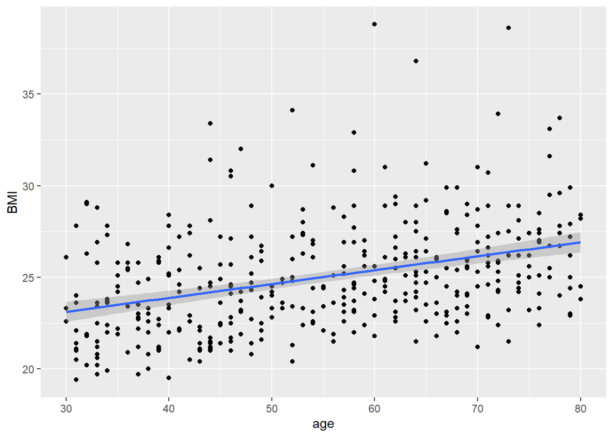

```r
# Plot the relationship between age and BMI
# 1. Data
ggplot(cholesterol) +
  # 2. Aesthetics
  aes(x = age, y = BMI) + # Use age as the x-value, BMI as the y-value
  # 4. Geoms
  geom_point() +
  stat_smooth(method = "lm")
```

### 2.4.2.1 Building our multiple linear regression model

From our visual analyses, we see that cholesterol increases with BMI. Furthermore, we see that BMI tends to increases with age. We will look at the association of age and cholesterol while holding BMI constant. This will indicate if the significance of our previous relationship between increasing cholesterol with increasing age was affected by BMI.

```r
# Define our multiple linear regression
ageBMIFit <- lm(chol ~ age + BMI, data = cholesterol)

# summarise the model
summary(ageBMIFit)
```

```
##
## Call:
## lm(formula = chol ~ age + BMI, data = cholesterol)
##
## Residuals:
##     Min      1Q  Median      3Q     Max
## -58.994 -15.793   0.571  14.159  62.992
##
## Coefficients:
##             Estimate Std. Error t value Pr(>|t|)
## (Intercept) 137.1612     9.0061  15.230  < 2e-16 ***
## age           0.2023     0.0795   2.544 0.011327 *
## BMI           1.4266     0.3822   3.732 0.000217 ***
## ---
## Signif. codes:  0 '***' 0.001 '**' 0.01 '*' 0.05 '.' 0.1 ' ' 1
##
## Residual standard error: 21.34 on 397 degrees of freedom
## Multiple R-squared:  0.07351,    Adjusted R-squared:  0.06884
## F-statistic: 15.75 on 2 and 397 DF,  p-value: 2.62e-07
```

### 2.4.3 Interpreting our multiple linear regression results

Our equation would now look like $y = 137.16 + 0.20age + 1.43BMI$.

The estimated increase in mean serum cholesterol after one year while holding BMI constant is 0.20 mg/dl. This increase is less than our previous value of 0.31 mg/dl. Why do the estimates differ?

Before, we were not controlling for BMI. In comparison to our simpler `agefit` model, our estimates of the age associated increase in mean cholesterol is now for subjects with the *same* BMI and not for subjects with *irrespective* of their BMI.

It looks like both age and BMI are significant. From the Adjusted R-squared value, it looks like we now explain nearly 7% of our variability. Still, we might want to verify if adding BMI actually made a difference to the model.

## 2.5.0 Comparing models with `anova()`

We can compare our two models with the `anova()` function. The output of our models, `ageFit` and `ageBMIFit`, are `lm` objects. With 2 `lm` objects, the `anova()` function tests the *models* against one another to see if their coefficients are significantly different and prints these results in an analysis of variance table.

Given a single `lm` object, it will test whether model *terms* of a model are significant - we will be using the function in this format later.

```r
# Here we're using the anova() function to compare the coefficients of two linear models.
# Think of this as a "secondary" use of the anova function. We are not running an ANOVA per se.

anova(ageFit, ageBMIFit)
```

```
## Analysis of Variance Table
##
## Model 1: chol ~ age
## Model 2: chol ~ age + BMI
##   Res.Df    RSS Df Sum of Sq      F    Pr(>F)
## 1    398 187187
## 2    397 180842  1    6345.8 13.931 0.0002174 ***
## ---
## Signif. codes:  0 '***' 0.001 '**' 0.01 '*' 0.05 '.' 0.1 ' ' 1
```

### 2.5.1 Interpreting the result of our comparison by the F-value

Our second model is significantly different from our first model. What is this significance based on?

The significance is a probability based on an **F-test**. While the t-test tells you if two means (from a single variable in our case) are statistically significant, an **F-test** tells you if a group of variables is jointly significant.

The F-test compares the joint effect of all variables together, a large F value means ‘something’ is significant. We can calculate the F-value ourselves from the information provided in the table

| Model | Res.df | RSS | df | Sum of Squares | F | Pr(>F) |
| --- | --- | --- | --- | --- | --- | --- |
| 0 | 398 | 187187.5 | NA | NA | NA | NA |
| 1 | 397 | 180841.7 | 1 | 6345.76 | 13.93079 | 0.0002173567 |

Note that the Residual Sum of Squares (RSS) is also known as the Sum of Squared Errors (SSE). Recall that this is based on the difference between our data and our model estimates for the same data point ($y -\hat{y}$)<sup>2</sup>. This represents the total variation/difference between our observed data and the model we have generated.

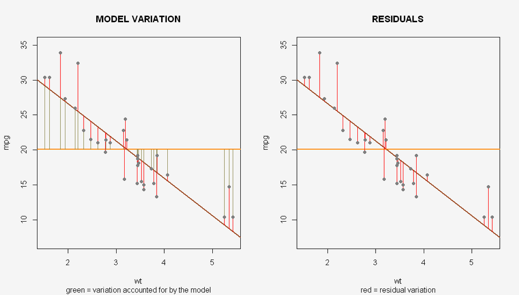

How do we measure the [fit of our model](https://stats.stackexchange.com/questions/172157/how-to-interpret-an-anova-table-comparing-full-vs-reduced-ols-models)?

There are two kinds of degrees of freedom to calculate in comparing the groups.

1. In the basic formula, we have $df_1$ or the $df_{between}$ which is calculated as $df_1 = k$, where $k$ is the number of groups or predictor variables. Aside from re-using $k$, we don’t use this value in our upcoming calculation.
2. In our **F-value** calculation, we’ll use $df_2$ or the $df_{within}$, which uses the formula $df_2 = N-k-1$ where $N$ is the total sample size minus. Note that `cholesterol` has 400 entries and we have two predictor variables. In our `summary()` output this is also denoted as `Res.df`.